# Bent Summer 2007

R. G. Cronce

12/19/2019

# Bent Brain Ticklers, Summer 2007

## Problem 1

```
The makers of Grunt, who claim
that their aftershave is so appealing
to women that users will have to fight
them off, are puzzled that some men
are using Phew, so they hired Judy
to investigate. She boarded a bus to
question the male passengers. The
first man said, "I use Grunt." Then,
the rest of the men in turn said, "I use
Grunt, but the man you just interviewed
uses Phew." Finally, the first
man added, "The last man you interviewed
uses Phew." Confused, Judy
asked a few of the men how many of
the male passengers used Phew. The
tallest man said "19," and the man she
had originally interviewed fourth after
him said "24." The fattest man said
"13," and the man she had originally
interviewed fifth after him said "28."
The nicest man said "24," and the man
she had originally interviewed sixth
after him said "13." If each man uses
either Grunt or Phew, but only Grunt
users tell the truth, how many men
use Phew?

-- Martin Hollis
```

TODO

```
Aaaaargh!
```

## Problem 2

```
On his trips to Monte Carlo, Sam
always gambles exactly $50 each night
on roulette. Usually, he just plunks
all his chips down on black (result
is double or nothing) and quits after
one spin, regardless of the outcome.
The probability of winning is 18/37.
One night he decides to change his
strategy by making $1 bets on black
until he either loses the $50 or gains
another $50. What is his probability
of winning with his new strategy?

-- Technology Review
```

Solution: Let’s try a Monte-Carlo analysis

```r
set.seed(42)
ntrials=10000
win=0
for (trial in 1:ntrials) {
    # Play until n=100 or n=0
    n=50
    while (T) {
        if (runif(1)<=18/37) {
            n=n+1
        } else {
            n=n-1
        }
        if (n==100) {
            win=win+1
            break
        }
        if (n==0) {
            break
        }
    }
}
print(paste0('Percent wins = ',win/ntrials))
```

```
## [1] "Percent wins = 0.0644"
```

Winning occurs a little more than 6% of the time:

```
0.0618  @ 10K trials
0.0655  @ 10K trials (seed=123)
0.0644  @ 10K trials (seed=42)
0.0579  @ 10K trials (seed=2020)
0.06401 @ 100K trials
```

This should be possible to calculate analytically. I suspect the result depends only on the relative likelihood of winning/losing 50 bets. So, the probability of winning/losing is;

```
(18/37)^50 vs. (19/37)^50
```

I am not sure about all the other probabilities (e.g W/L cancelling) but I suspect they all cancel out in the end.

```
          (18/37)^50
P = ----------------------- ~ 0.062775
    (18/37)^50 + (19/37)^50
```

I think we can prove this formula by examining a simpler problem and then calculating the results. Assume the original bankroll is 2 and the goal is either to win 2 or lose 2. For two rounds of betting we get:

```
B1 B2  Bankroll
---------------
L  L   0 --> loser: P = (19/37)^2
L  W   2 \ each has P = (18/37)*(19/37)
W  L   2 /
W  W   4 --> winner: P = (18/37)^2
```

In this case: you win (18/37)^2, you lose (19/37)^2, and you are back to the original problem the rest of the time. The cases where you end up back at the beginning could still end up with winning so the total probability of winning should be:

```
winner = (18/37)^2 + 2*(18/37)*(19/37)(18/37)^2 +
                     4*(18/37)^2*(19/37)^2*(18/37)^2 +
                     ...

       = (18/37)^2 * (1 + (2*18/37*19/37) + (2*18/37*19/37)^2 + ... )
       = (18/37)^2 * 1/(1-2*18/37*19/37)
       = 0.473
```

This is much higher than I thought but it agrees with the formula that I suspected above. For a bankroll of 2 we have:

```
         (18/37)^2
P = --------------------- = 0.4729927
    (18/37)^2 + (19/37)^2
```

Extending the argument to a bankroll of n we have:

```
         (18/37)^n
P = ---------------------
    (18/37)^n + (19/37)^n
```

Note that the longer you play the more likely you are to lose it all. No wonder casinos do so well.

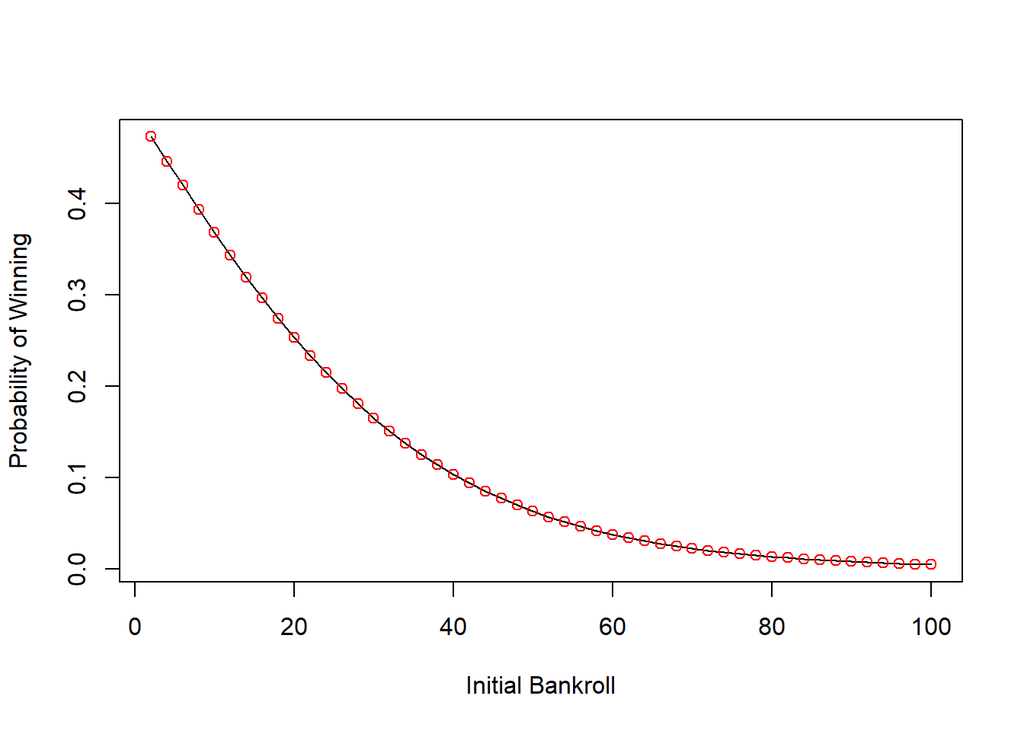

```r
n=seq(2,100,2)
p=(18/37)^n / ( (18/37)^n + (19/37)^n )
plot(n,p,type='l',xlab='Initial Bankroll',ylab='Probability of Winning')
points(n,p,col='red')
```

## Problem 3

```
Different letters are different digits;
same letter is same digit throughout.

See picture

-- Eric R. Emmet
```

Solution: not solved in the cryptic arithmetic notebook

```
Needs a solution.

          - - a -
    -----------------
- - | d - - - - x
      k - -
      ---------------
          - -
          t -
          -----------
          m - -
          m - -
          -----------
          x - x
          h - -
          -----------
            k -
```

## Problem 4

```
On the island of Approxima, all
measurements are only to the closest
inch. Alex, who makes yardsticks, has
realized that he doesn't have to put
marks at each inch to still be able to
measure all integral number of inches
from 1 through 36, inclusive. Distances
are measured between two marks,
or between a mark and an end of the
ruler, or between the two ends of the
ruler. For example, a foot ruler only
needs marks at 1, 2, 6, and 9 inches in
order to measure all distances from 1
inch through 12 inches, inclusive. Using
eight marks, where does Alex put
them on his yardsticks?

-- The Numerology of Dr. Matrix
by Martin Gardner
```

Solution:

```
We need to measure 1-36 inches (integer)
The distances can be:

(1) from the end to a marker
(2) from the opposite end to a marker
(3) between two markers
(4) between two ends.

I tried some guessing - but nothing worked.
```

OK - time to give up and try exhaustive search. Let us assume that markers are required at locations 1 and 2. The remaining markers can be at any location from 3 to 33. That didn’t work. Modify the search to look for 8 markers over the full range of the yardstick. This is **SLOW** since it looks at choose(35,8) combinations (~23.5e6) and needs to calculate 10x10 outer with logic to find the unique values for each combination.

The two solutions that are found are actually just reflections of one solution.

```r
maxlen=0

t1=Sys.time()
for (m1 in 1:35) {
    for (m2 in (m1+1):35) {
        for (m3 in (m2+1):35) {
            for (m4 in (m3+1):35) {
                for (m5 in (m4+1):35) {
                    for (m6 in (m5+1):35) {
                        for (m7 in (m6+1):35) {
                            for (m8 in (m7+1):35) {
                                x=c(0,36,m1,m2,m3,m4,m5,m6,m7,m8)
                                # print(x)
                                m=length(unique(as.vector(abs(outer(x,x,"-")))))
                                if (m>maxlen) { maxlen=m; bestx=x }
                                if (m==37) {
                                    print(sort(x))
                                }
                            }
                        }
                    }
                }
            }
        }
    }
}
```

```
##  [1]  0  1  3  6 13 20 27 31 35 36
##  [1]  0  1  5  9 16 23 30 33 35 36
```

```r
t2=Sys.time()
print(t2-t1)
```

```
## Time difference of 9.160833 mins
```

There are two solution sets that work:

```
end    ....... markers ......    end
0  --- 1  3  6 13 20 27 31 35 --- 36
0  --- 1  5  9 16 23 30 33 35 --- 36
```

This may be easier to understand by looking at the difference between marks. A length may be measured based on a difference or the sum of adjacent differences. For the two sets of markers we have:

```
1 2 3 7 7 7 4 4 1
1 4 4 7 7 7 3 2 1
```

By summing adjacent sections near the left/right ends you can achieve all the smaller numbers. The center groups are only needed to get a coarse level and then use pieces of the edges to achieve fine tuning to the desired value.

The two sets of diffs are just reflections of each other so these really represent the same solution.

## Problem 5

```
You have eight objects of eight different
weights, which have been partially
ordered. That is, the order of the first
four is known among themselves, and
the order of the second four is known
among themselves. What is the minimum
number of weighings on a two-pan
balance to ensure that the eight weights
can be ordered in all cases?

-- Super-Puzzles, Jean-Claude Baillif
```

TODO

```
I am going to guess that the answer is 3.
```

## Bonus

```
A student pilot, initially located
at coordinates (x0,y0), rashly
decides to fly under the Golden Gate
Bridge, the ends of which are located at
(-1,0) and (1,0). These end points subtend
a visual angle Q (vertex at the
student's airplane), and all movement
and measurements lie in the same
X-Y plane. He flies along a path that
maximizes the instantaneous rate of
increase of Q. What is the equation of
his flight path? Assume the X-Y plane
is parallel to a flat ocean.

-- Byron R. Adams, TX A '58
```

Solution?

```
I don't really understand this problem.

Does the maximization of the instantaneous rate of
increase of Q define a full flight path?

The angle from the left end of the bridge (-1,0) to
the student plane is:

    alpha1 = atan(y0/(x0+1))

The angle from the right end of the bridge (1,0) to
the student plane is:

    alpha2 = atan(y0/(x0-1))

The angle at the vertex is just the difference between
these two:

    Q = alpha1-alpha2
      = atan(y0/(x0+1)) - atan(y0/(x0-1))

How do we maximize the rate of change?

    maximize( (dq/dx)^2 + (dq/dy)^2 )?

This is maximized (e.g. d^2/dx^2 and d^2/dy^2 = 0) when:

    x = sqrt(1-y^2), or
    x = 0, or
    x = -sqrt(1-y^2)

Or,

    x=0 --> fly down the y axis.
    x^2 = 1-y^2 --> x^2+y^2 = 1  --> circle with radius = 1
```

## Double Bonus

```
If A, B, and C are the
measures of the angles of a plane triangle,
what are the values of L and H in

L <= sin(3A) + sin(3B) + sin(3C) <= H

when equality holds? Prove your answers.

-- Tenth U.S.A. Mathematical
Olympiad (1981)
```

Solution:

```
I don't agree with the published solution.  They take the equation
below and then diff wrt A and set it equal to zero.  The result is
that:

    cos(3*A) + cos(3*A+3*B) = 0

and then they conclude that A = (pi-3*B)/6 which leads to a min of 0.

I think they are missing the case of A = (3*pi-3*B)/6 which lead to a
much deeper min.  See the contour and 3D plots below for the region
where min < 0.

This is fairly obvious if you consider a very tall, narrow triangle.
Each base angle is ~90 degrees and the apex is nearly 0.  The value
of sin(3*A) and sin(3*B) is each nearly -1 and the apex is 0 so the
sum must approach:

    limit --> -2

You can see this in the contour plot near a=1.57 where for low values
of b the min is very negative (angle c ~ 90 degrees) and for b near
1.57 (about 90 degrees) the apex angle will be zero.  The same min
occurs for low values of a with b~c~1.57.  These are all really
the same condition just a swap of a, b and c.

Algebraically I don't have much.  About all I can figure out is that

C = pi-(A+B) so:

L <= sin(3A) + sin(3B) + sin(3A+3B) <= H

I can manipulate this to:

L <= sin(3A)*(1+cos(3B))+sin(3B)*(1+cos(3A)) <= H

But that is about it.

I can explore the solution space numerically:
```

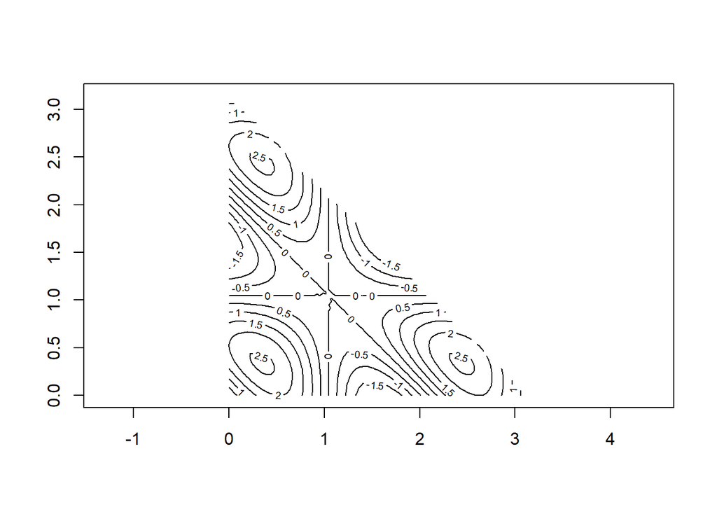

```r
foo = function(a,b) {
    return(sin(3*a)+sin(3*b)+sin(3*a+3*b))
}

a=seq(0,pi,length=100)
b=seq(0,pi,length=100)

zzz=outer(a,b,foo)
xxx=outer(a,b,"+")
zzz=ifelse(xxx>pi,NA,zzz)


contour(a,b,zzz,asp=1)
```

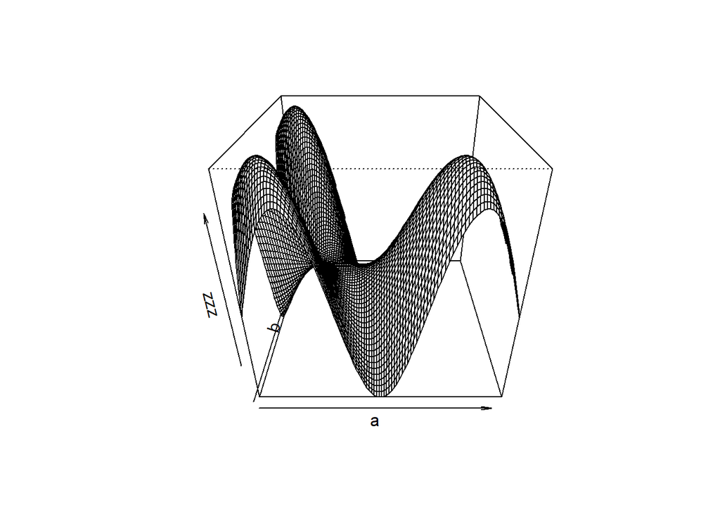

```r
persp(a,b,zzz,phi=30)
```